# degree-adverbs

erin

11/12/2014

# Intensity of degree adverbs

Hypothesis: adverbs of degree, like “somewhat” and “extremely”, modify the adjectives they describe in proportion to the cost of uttering them. For example, if “inordinately” is more costly to utter than “very”, the former will have a stronger meaning than the latter.

This cost might manifest in syllable length or in surprisal (how unlikely is that word to be said?).

## Intro

Degree adverbs are adverbs that modify scalar adjectives by increasing or decreasing the extent to which that adjective applies. For example, “very” and “extremely” are degree adverbs that intensify the adjectives they modify, and “moderately” and “sorta” are degree adverbs that deintensify the adjectives they modify.

How do we know how much a degree adverb will modify an adjective’s meaning? In this paper, we hypothesize that communicative pressures might determine the meanings of these degree adverbs: those that are easier to retrieve from memory and to say will have correspondingly weaker meanings, and those that are more costly to utter will have stronger meanings. This hypothesis predicts that longer degree adverbs will have stronger meanings, but also that the more commonly used a particular degree adverb is (and therefore the more accessible it is) the weaker its meaning will become.

Molly, Elise, and Mike found that longer words tend to have more complex meanings associated with them, and learners tend to use this information in interpreting novel words. They hypothesized that lexicalized in-the-moment communicative pressures might be responsible for this complexity bias.

## Experiment 1: intensifiers

In Experiment 1, we tested whether intensifying degree adverbs have stronger meanings (higher prices when paired with ``expensive’’) when they have higher communicative cost.

### Method

#### Materials

We consider surprisal and length in syllables as possible sources of communicative cost. We calculate the surprisal of a word (-log(P(word))) by approximating the probability of a word as the proportion of occurances in the Google Web 1T 5-grams database.

Here are the intensifiers, surprisals, and syllable lengths in this experiment:

```
##          ngram frequency syllables
## 1  exceedingly    977435         4
## 2  excessively    877280         4
## 3       really 148918637         2
## 4   enormously   1011751         4
## 5       hugely   1074430         2
## 6        crazy  13048828         2
## 7     insanely    359644         3
## 8       wildly   1414395         3
## 9        super  16902202         2
## 10    horribly    819111         3
## 11   extremely  21862963         3
## 12        very 292897993         2
## 13      vastly   1311113         2
## 14       quite  55269390         1
## 15    terribly   1906059         3
## 16  uncommonly    135747         4
## 17    slightly  28523541         2
## 18    somewhat  14075405         2
## 19  moderately   1922506         4
## 20       a bit  33634149         2
## 21       a tad    775965         2
## 22     sort of  19227411         2
## 23     kind of  43691232         2
```

For the set of degree adverbs I studied, the correlation between my two possible measure of cost, surprisal and syllable length, is 0.6809.

I asked participants the prices of different “*[adverb]* expensive” watches, laptops, and coffee makers. Prices were elicited with free response, and trials looked like this:

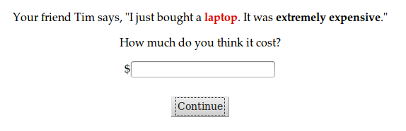

### Results

In a simple ANOVA, participant (`workerid`) predicted responses better than item and intensifier.

```
## Analysis of Variance Table
##
## Response: price
##                            Df   Sum Sq  Mean Sq F value Pr(>F)
## intensifier                15 4.38e+10 2.92e+09    0.57 0.9002
## item                        2 1.20e+10 6.01e+09    1.17 0.3117
## workerid                   38 3.64e+11 9.57e+09    1.86 0.0017 **
## intensifier:item           30 1.17e+11 3.91e+09    0.76 0.8201
## intensifier:workerid      570 1.60e+12 2.80e+09    0.54 1.0000
## item:workerid              76 2.21e+11 2.91e+09    0.56 0.9987
## intensifier:item:workerid 607 9.44e+11 1.56e+09    0.30 1.0000
## Residuals                 533 2.74e+12 5.15e+09
## ---
## Signif. codes:  0 '***' 0.001 '**' 0.01 '*' 0.05 '.' 0.1 ' ' 1
```

This probably has something to do with the fact that some participants gave answers that were insanely high.

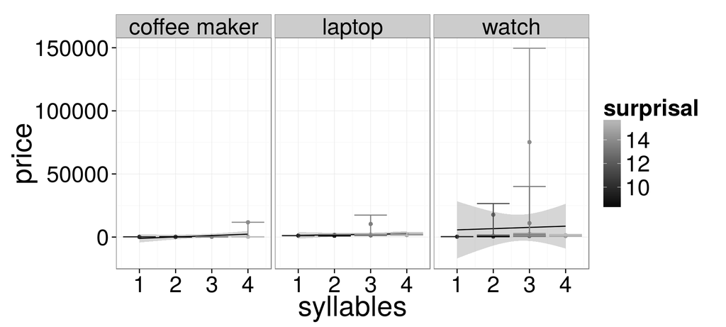

I ran a mixed effect model with syllables and surprisal as fixed effects and workerid and item as random effects, which found no significant effect of either fixed effect on response.

[output not shown]

```
## Linear mixed model fit by REML ['merModLmerTest']
## Formula: price ~ (surprisal + syllables) + (1 | item) + (1 | workerid) +
##     (surprisal + syllables | workerid) + (surprisal + syllables |
##     item)
##    Data: intensifiers
##
## REML criterion at convergence: 46196
##
## Scaled residuals:
##    Min     1Q Median     3Q    Max
##  -1.98  -0.03   0.00   0.01  39.97
##
## Random effects:
##  Groups     Name        Variance Std.Dev. Corr
##  workerid   (Intercept) 4.71e+08 21691
##             surprisal   9.18e+06  3031    -1.00
##             syllables   2.22e+06  1488     1.00 -1.00
##  workerid.1 (Intercept) 0.00e+00     0
##  item       (Intercept) 2.46e+07  4957
##             surprisal   6.51e+05   807    -1.00
##             syllables   1.23e+06  1109     1.00 -1.00
##  item.1     (Intercept) 0.00e+00     0
##  Residual               3.05e+09 55233
## Number of obs: 1872, groups:  workerid, 39; item, 3
##
## Fixed effects:
##             Estimate Std. Error       df t value Pr(>|t|)
## (Intercept) -3933.06    8863.63    10.48   -0.44     0.67
## surprisal     616.66    1048.13     6.42    0.59     0.58
## syllables    -213.25    2051.30     9.36   -0.10     0.92
##
## Correlation of Fixed Effects:
##           (Intr) srprsl
## surprisal -0.882
## syllables  0.309 -0.685
```

However, every participant saw every combination of intensifier and item, so I can z-score by `workerid` and `item` which standardizes participants beliefs about different items’ prices and the ranges of those prices.

When I do this, I find significant effects of surprisal and syllable length.

```
##
## Call:
## lm(formula = zzprice ~ surprisal * syllables, data = intensifiers)
##
## Residuals:
##    Min     1Q Median     3Q    Max
## -3.490 -0.593 -0.085  0.534  3.968
##
## Coefficients:
##                     Estimate Std. Error t value Pr(>|t|)
## (Intercept)          -4.4527     0.4225  -10.54  < 2e-16 ***
## surprisal             0.3336     0.0346    9.65  < 2e-16 ***
## syllables             1.3571     0.1811    7.49  1.0e-13 ***
## surprisal:syllables  -0.0949     0.0136   -6.96  4.8e-12 ***
## ---
## Signif. codes:  0 '***' 0.001 '**' 0.01 '*' 0.05 '.' 0.1 ' ' 1
##
## Residual standard error: 0.885 on 1868 degrees of freedom
## Multiple R-squared:  0.135,  Adjusted R-squared:  0.134
## F-statistic: 97.6 on 3 and 1868 DF,  p-value: <2e-16
```

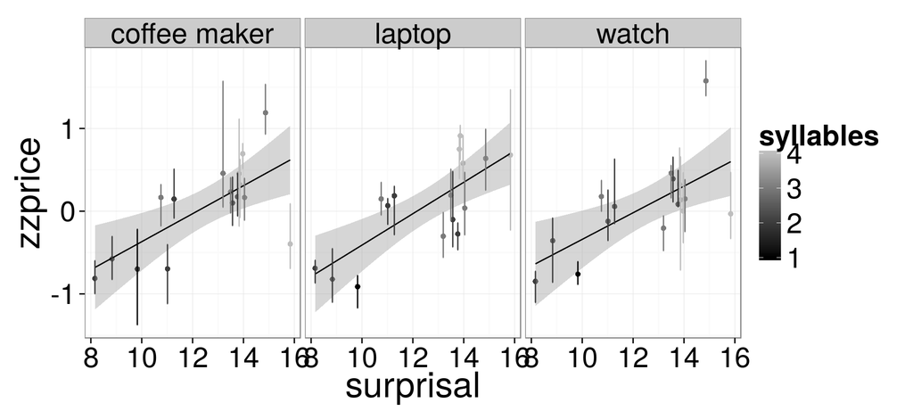

I also find a significant negative interaction between syllables and suprisal.

### Conclusion

So it seems like there is some relationship between the cost of an intensifier and its strength.

I was concerned that the relationship between surprisal and strength might be an effect of more extreme objects being less common and therefore talked about less, which would result in words that describe those objects being rarer. So I ran Experiment 2 to test that hypothesis.

## Experiment 2: deintensifiers

Experiment 2 tests a competing hypothesis that might explain some of the data in Experiment 1.

Supposed that objects that are more extreme along a scale are less common and therefore talked about less. Then words that describe them (adverbs of degree that are quite strong) would be more rare. Thus the surprisal at these words would be a consequenct of their meaning rather than a cause. Were this the case, then stronger *deintensifying* adverbs of degree (e.g. “somewhat” or “moderately”) would be more common because they describe more typical items that are more moderate along a scale.

### Method

#### Materials

7 deintensifiers.

#### Participants

40 Turkers.

### Results

I found no evidence for the competing hypothesis (that stronger deintensifying adverbs of degree are more common). I also did not find evidence that stronger deintensifying degree adverbs are rarer or longer: in fact, I found a slight positive correlation between syllable length and response, implying that longer deintensifying adverbs are *less* strong. Though since I only have one example of a deintensifying adverb of any syllable length other than 2, this finding should be taken with a grain of salt.

```
##
## Call:
## lm(formula = zzprice ~ surprisal * syllables, data = deintensifiers)
##
## Residuals:
##    Min     1Q Median     3Q    Max
## -2.267 -0.683 -0.156  0.666  2.354
##
## Coefficients: (1 not defined because of singularities)
##                     Estimate Std. Error t value Pr(>|t|)
## (Intercept)          -0.5729     0.3754   -1.53     0.13
## surprisal            -0.0236     0.0198   -1.19     0.23
## syllables             0.0837     0.0406    2.06     0.04 *
## surprisal:syllables       NA         NA      NA       NA
## ---
## Signif. codes:  0 '***' 0.001 '**' 0.01 '*' 0.05 '.' 0.1 ' ' 1
##
## Residual standard error: 0.925 on 1369 degrees of freedom
## Multiple R-squared:  0.00312,    Adjusted R-squared:  0.00167
## F-statistic: 2.15 on 2 and 1369 DF,  p-value: 0.117
```

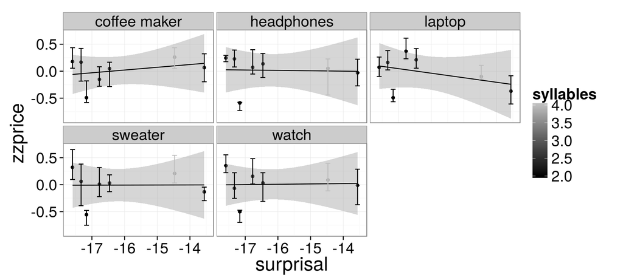

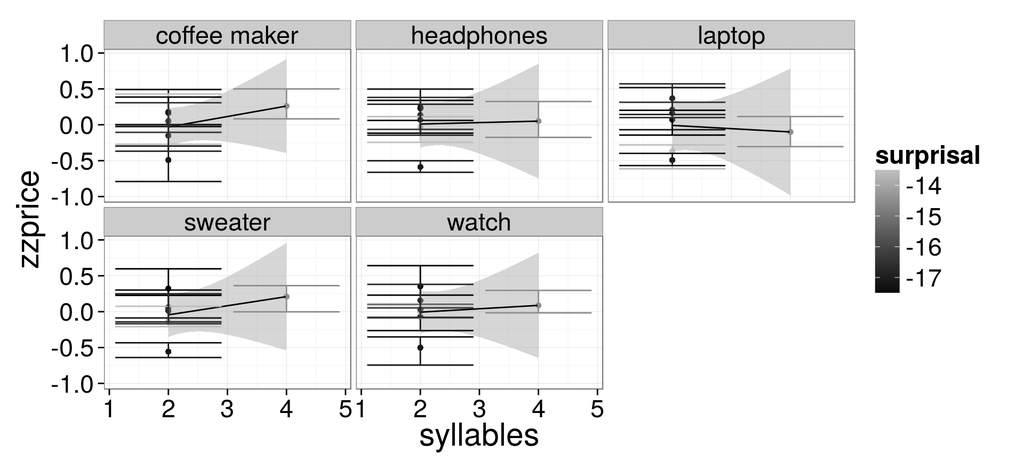

### Conclusion

This absence of a significant result for surprisal might be a result of floor effects or a more subtle meaning than I assumed for deintensifiers. Either way, the significance of syllable length in Experiment 1 cannot be explained with this competing hypothesis.

## Experiment 3:

In Experiment 3, I tried to replicate my findings from Experiment 1 (that stronger intensifying degree adverbs happen to have higher costs) and from Experiment 2 (that stronger deintensifying adverbs are not necessarily more common). This time I tested all participants on all combinations of item and adverb, where adverbs were either intensifying or deintensifying degree adverbs. I only ran this experiment on 10 participants.

### Method

#### Participants

This was only run on 10 participants.

#### Method

Slightly different set of intensifiers and deintensifiers.

### Results

I found a significant effect of suprisal, but no significant effect of syllable length above and beyond surprisal.

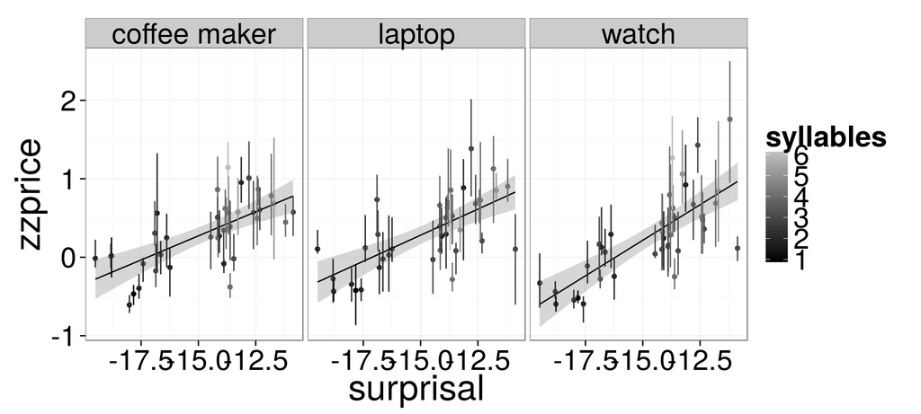

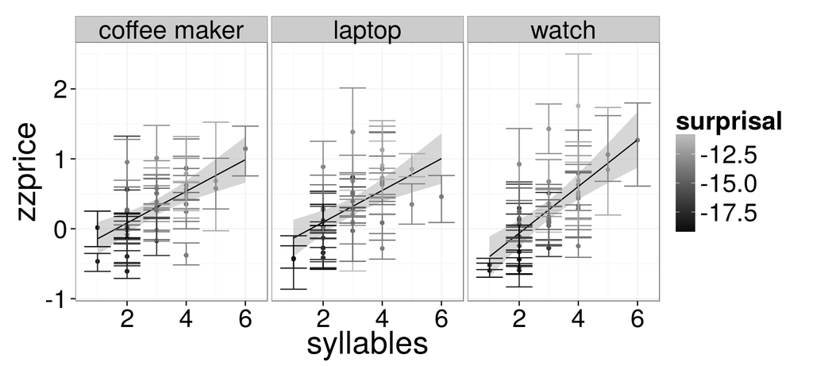

```
##
## Call:
## lm(formula = zzprice ~ surprisal * syllables, data = intensifiers)
##
## Residuals:
##    Min     1Q Median     3Q    Max
## -3.401 -0.578 -0.121  0.502  6.556
##
## Coefficients:
##                     Estimate Std. Error t value Pr(>|t|)
## (Intercept)          1.77664    0.58341    3.05  0.00238 **
## surprisal            0.12374    0.03748    3.30  0.00099 ***
## syllables            0.02674    0.20273    0.13  0.89507
## surprisal:syllables -0.00616    0.01419   -0.43  0.66451
## ---
## Signif. codes:  0 '***' 0.001 '**' 0.01 '*' 0.05 '.' 0.1 ' ' 1
##
## Residual standard error: 0.881 on 1136 degrees of freedom
## Multiple R-squared:  0.134,  Adjusted R-squared:  0.132
## F-statistic: 58.7 on 3 and 1136 DF,  p-value: <2e-16
```

Among the deintensifiers, I found a significant negative effect of surprisal and positive effect of syllables as well as a significant positive interaction between the two.

```
## facet_wrap(item)
```

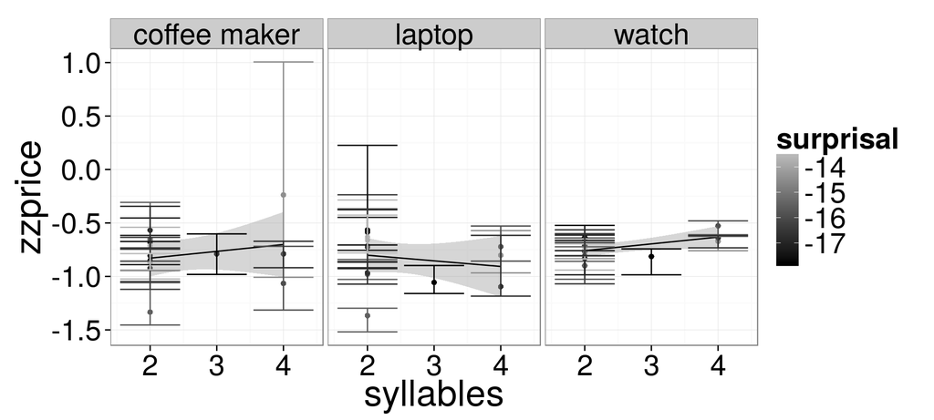

```
## facet_wrap(item)
```

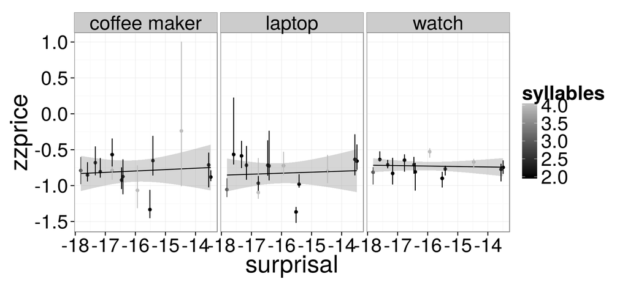

```
##
## Call:
## lm(formula = zzprice ~ surprisal * syllables, data = deintensifiers)
##
## Residuals:
##    Min     1Q Median     3Q    Max
## -2.018 -0.251 -0.033  0.190  6.830
##
## Coefficients:
##                     Estimate Std. Error t value Pr(>|t|)
## (Intercept)          -3.3174     1.2237   -2.71    0.007 **
## surprisal            -0.1562     0.0770   -2.03    0.043 *
## syllables             1.1340     0.4989    2.27    0.024 *
## surprisal:syllables   0.0700     0.0314    2.23    0.026 *
## ---
## Signif. codes:  0 '***' 0.001 '**' 0.01 '*' 0.05 '.' 0.1 ' ' 1
##
## Residual standard error: 0.585 on 416 degrees of freedom
## Multiple R-squared:  0.0134, Adjusted R-squared:  0.00631
## F-statistic: 1.89 on 3 and 416 DF,  p-value: 0.131
```